# Lab Introduction à GitHub avec RStudio en individuel

Aurélien Nicosia

R est le nom du langage de programmation lui-même et RStudio est une interface pratique.

L’objectif principal de ce laboratoire est de vous présenter Git et GitHub, qui est le système de collaboration et de contrôle de version utilisé quand on programme en R.

Git est un système de contrôle de version (comme les fonctionnalités “Suivi des modifications” de Microsoft Word sur les stéroïdes) et GitHub est l’environnement pour vos projets basés sur Git sur Internet (comme Dropbox mais beaucoup, beaucoup mieux).

Et pour simplifier, pour le moment, la gestion des versions, il s’agit d’un laboratoire en individuel. Dans la seconde portion de l’atelier, vous apprendrez à collaborer à plusieurs.

# Installer tout ce que vous avez besoin (seulement à la maison)

- Installer R https://cran.r-project.org/

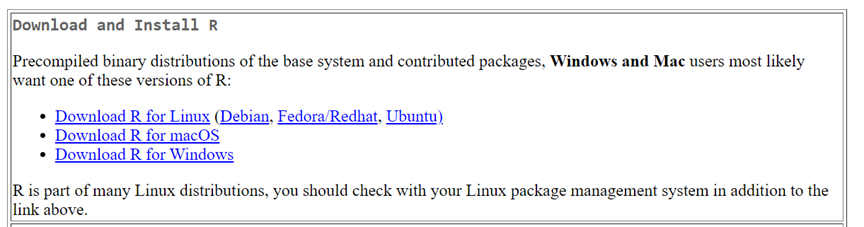

- Installer RStudio https://www.RStudio.com/products/RStudio/download/#download

[figure not shown]

- Installer Git : o Windows : https://gitforwindows.org/

o Mac : Installez les outils de ligne de commande Xcode (pas tous Xcode), qui incluent Git.

# Connecter GitHub et RStudio

Vous devriez déjà avoir reçu une invitation à rejoindre l’organisation GitHub pour ce cours. Vous devez accepter l’invitation avant de passer à l’étape suivante.

Pour avoir accès à chaque nouveau dépôt, vous devrez commencer par les étapes suivantes.

# Commençons

- Cliquez sur le lien du dépôt “travail-individuel-[VOTRE_IDENTIFIANT_GITHUB]” que vous avez dû recevoir dans votre e-mail pour créer votre dépôt GitHub (que nous appellerons désormais “dépôt”) pour ce laboratoire. Ce dépôt contient un exemple très simple pour vous familiariser avec Github.
- Sur GitHub, cliquez sur le bouton vert **Code**, sélectionnez **Local**, puis l’onglet **HTTPS** (cela peut déjà être sélectionné par défaut, et si c’est le cas, vous verrez le texte **Cloner avec HTTPS** comme dans l’image ci-dessous). Cliquez sur l’icône du presse-papiers pour copier l’URL du référentiel.

[figure not shown]

- Accédez à RStudio et dans file -> New Projet. Créez un nouveau projet **version control**

[figure not shown]

- Choisir l’option Git:

[figure not shown]

- Copiez et collez l’URL de votre devoir dans la boîte de dialogue :

[figure not shown]

## On s’échauffe

Dans le fichier README, suivez les instructions suivantes, à savoir:

- Inscrivez votre nom et prénom dans le fichier README.md

### Validation des modifications

Accédez ensuite au volet Git de votre RStudio (en haut à droite)

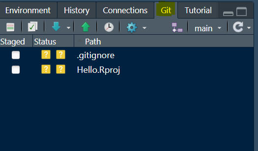

Si vous avez apporté des modifications à votre fichier README, vous devriez le voir répertorié ici. Cliquez dessus pour le sélectionner dans cette liste puis cliquez sur **Diff**. Cela vous montre la *différence* entre le dernier état validé du document et son état actuel qui inclut vos modifications. Si vous êtes satisfait de ces changements, écrivez “Mettre à jour le nom de l’auteur” dans la case **Commit message (Message de validation)** et appuyez sur **Commit (Valider)**.

[figure not shown]

Vous n’avez pas valider (commit) après chaque modification, cela deviendrait assez fastidieux. Vous devriez envisager de valider des nouveautés de vos fichiers qui sont *significatifs pour vous* .

### Allons vérifier sur Github

Maintenant que vous avez enregistré (commit) le changement dans le README, allez voir dans Github si cela à changer.

Rien n’as chagné! Est-ce normal?

Oui bien sur, nous avons seulement fait un enregistrement en local (commit)!

### Autres directives

Vous devez maintenant créer un script .r avec du code dedans (ce que vous voulez) et l’enregistrer dans le repertoire de travail du projet Rstudio.

Vous pouvez enregistrer (commit) la modification en ajoutant un message instructif.

### Poussons dans Github le résultat

Maintenant que vous avez effectué une mise à jour et validé les modifications, il est temps de diffuser ces modifications sur le Web ! Ou plus précisément, à votre dépôt sur GitHub.

Pourquoi?

Pour que les autres puissent voir vos modifications.

🧶 ✅ ⬆️ *Youpi, vous avez terminé ! On va maintenant voir comment collaborer en équipe*